# CIND 123: Data Analytics Basic Methods: Assignment-3

## Question 3 [15 Pts]

This question makes use of package “ISwR”. Please load `airquality` dataset as following:

```r
# or install.packages("ISwR")
library(ISwR)
data(airquality)
str(airquality)
```

```
## 'data.frame':    153 obs. of  6 variables:
##  $ Ozone  : int  41 36 12 18 NA 28 23 19 8 NA ...
##  $ Solar.R: int  190 118 149 313 NA NA 299 99 19 194 ...
##  $ Wind   : num  7.4 8 12.6 11.5 14.3 14.9 8.6 13.8 20.1 8.6 ...
##  $ Temp   : int  67 72 74 62 56 66 65 59 61 69 ...
##  $ Month  : int  5 5 5 5 5 5 5 5 5 5 ...
##  $ Day    : int  1 2 3 4 5 6 7 8 9 10 ...
```

1. [5 Pts] Plot a histogram to assess the normality of the `Ozone` variable, then explain why it does not appear normally distributed.

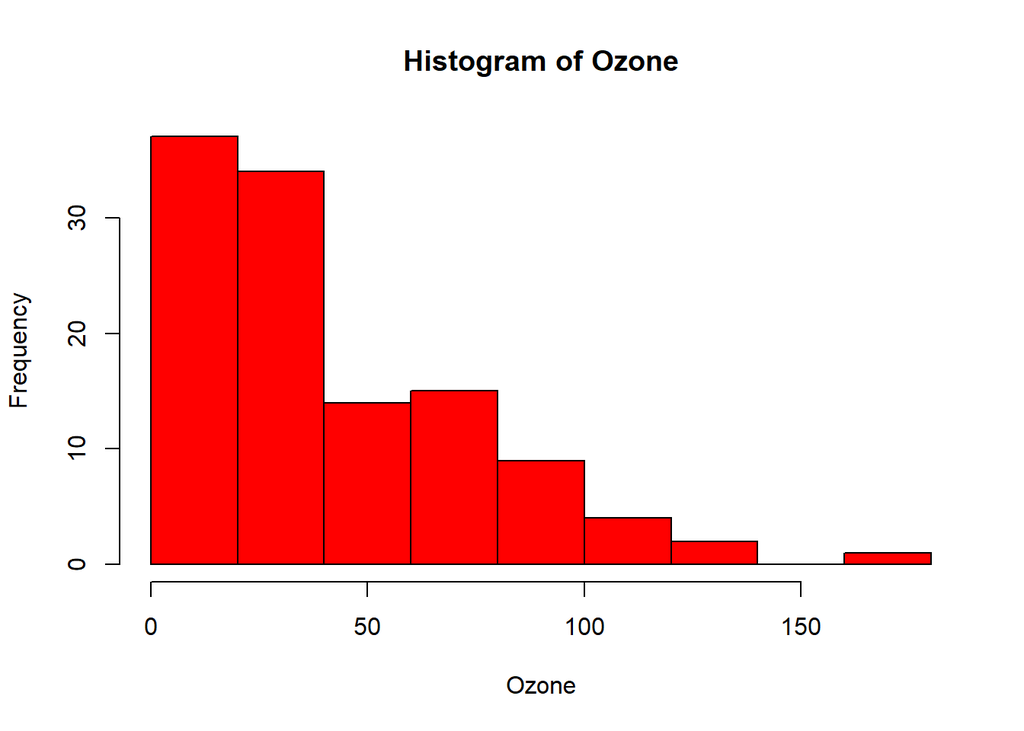

```r
## Loading the ISwR package
library(ISwR)

## Loading the airquality dataset
data(airquality)

## Plotting a histogram of the Ozone variable
hist(airquality$Ozone, main = "Histogram of Ozone", xlab = "Ozone", col = "red", border = "black")
```

2. [5 Pts] Create a boxplot that shows the distribution of `Ozone` in each month. Use different colors for each month.

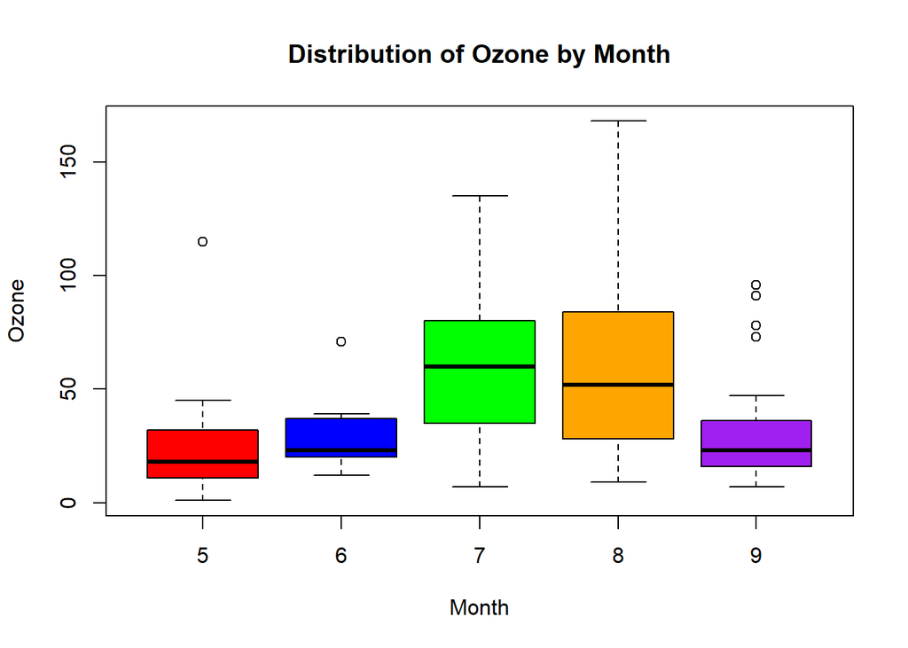

```r
## Loading the ISwR package
library(ISwR)

## Loading the airquality dataset
data(airquality)

## Setting different colors for each month
month_colors <- c("red", "blue", "green", "orange", "purple")

## Creating a boxplot of Ozone by month
boxplot(Ozone ~ Month, data = airquality, col = month_colors,
        main = "Distribution of Ozone by Month",
        xlab = "Month", ylab = "Ozone")
```

3. [5 Pts] Create a matrix of scatterplots of all the numeric variables in the `airquality` dataset (i.e. Ozone, Solar.R, Wind and Temp.) (Hint: investigate pairs() function)

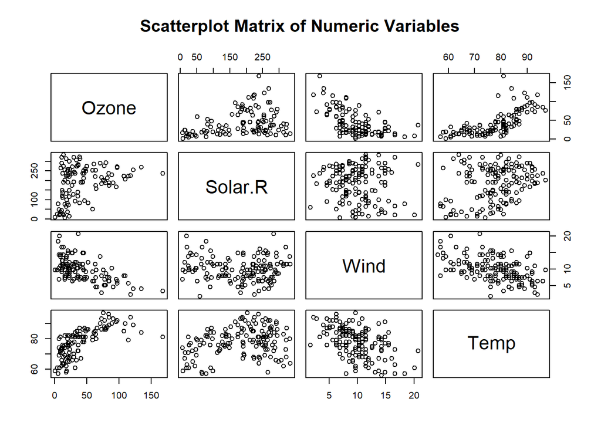

```r
## Loading the ISwR package
library(ISwR)

## Loading the airquality dataset
data(airquality)

## Selecting the numeric variables
numeric_vars <- c("Ozone", "Solar.R", "Wind", "Temp")

## Creating a matrix of scatterplots
pairs(airquality[numeric_vars], main = "Scatterplot Matrix of Numeric Variables")
```

## Question 4 [25 Pts]

Many times in data analysis, we need a method that relies on repeated random sampling to obtain numerical results. The underlying concept is to use randomness to solve problems. In fact, this is a mathematical technique, which is used to estimate the possible outcomes of an uncertain event and is called the *Monte Carlo Method*.

1. [5 Pts] The Monte Carlo Method uses random numbers to simulate some process. Here the process is rolling a die 20 times. Assume the die is fair. What is the probability of success or getting an even number in rolling the die once?

```r
## Defining the total number of possible outcomes
total_outcomes <- 6

## Defining the number of even numbers
even_numbers <- 3

## Calculating the probability of getting an even number
probability_even <- even_numbers / total_outcomes

## Printing the result
print(paste("Probability of getting an even number when rolling the die once:", probability_even))
```

```
## [1] "Probability of getting an even number when rolling the die once: 0.5"
```

2. [10 Pts] Define a function named `one.trial`, that simulates a single round of rolling a die 20 times and returns true if the number of even numbers is > 5.

```r
## Defining the function one.trial
one.trial <- function() {
  ## Simulating rolling a die 20 times
  rolls <- sample(1:6, 20, replace = TRUE)

  ## Counting the number of even numbers
  even_count <- sum(rolls %% 2 == 0)

  ## Returning TRUE if the number of even numbers is > 5, otherwise return FALSE
  return(even_count > 5)
}

## Testing the function
result <- one.trial()
print(result)
```

```
## [1] TRUE
```

3. [5 pts] Repeat the function `one.trial` for `N = 100,000` times and sum up the outcomes and store the result in a variable named `desired.output`. Compute the probability of getting more than 5 times of even numbers by using relative frequency.

```r
## Defining the function one.trial
one.trial <- function() {
  ## Simulating rolling a die 20 times
  rolls <- sample(1:6, 20, replace = TRUE)

  ## Counting the number of even numbers
  even_count <- sum(rolls %% 2 == 0)

  ## Returning TRUE if the number of even numbers is > 5, otherwise return FALSE
  return(even_count > 5)
}

## Setting the number of trials
N <- 100000

## Initializing variable to store the number of desired outcomes
desired.output <- 0

## Performing N trials
for (i in 1:N) {
  ## Running one trial
  outcome <- one.trial()

  ## Updating the count of desired outcomes
  desired.output <- desired.output + outcome
}

## Computing the probability of getting more than 5 times of even numbers using relative frequency
probability <- desired.output / N

## Printing the result
print(paste("Probability of getting more than 5 times of even numbers:", probability))
```

```
## [1] "Probability of getting more than 5 times of even numbers: 0.97971"
```

4. [5 pts] Use the Binomial formula you learned before to calculate such probability and Compare it with the probability value obtained in part (c).

```r
## Defining the parameters
n <- 20 # Number of trials
p <- 1/2 # Probability of success in a single trial
k <- 5 # Number of successes we're interested in

## Calculating the probability using the binomial formula
binomial_probability <- 1 - pbinom(k, size = n, prob = p)

## Printing the result
print(paste("Probability of getting more than 5 times of even numbers using the binomial formula:", binomial_probability))
```

```
## [1] "Probability of getting more than 5 times of even numbers using the binomial formula: 0.979305267333984"
```

Congratulations! you have completed the first run of the Monte Carlo simulation.

If there is further interest, put all the above logic in a function, and call it 50 times at least, and store the results in a vector called Prob then take the mean of Prob vector to be more accurate.

** End of Assignment **